# Visualizing Matrix Multiplication

In the videos on **Linear Transformation and Matrices**, you learned how a vector can be decomposed into it's basis vectors $\hat{i}$ and $\hat{j}$. You also learned that you can tranform a vector by multiplying that vector's $x$ and $y$ values by the *transformed* basis vectors, $\hat{i_T}$ and $\hat{j_T}$, summing their results (see *Equation 1*).

$\hspace{1cm}\textit{transformed } \vec{v} = x\mathbin{\color{green}{\hat{i_T}}} +\, y\, \mathbin{\color{red}{\hat{j_T}}} $

$\hspace{2.3cm}$*Equation 1*

You learned how this method of transforming a vector through use of the *transformed* basis vectors is the same as matrix multiplication (see *Equation 2*).

$\hspace{1cm} \begin{bmatrix} \mathbin{\color{green}a} & \mathbin{\color{red}b}\\ \mathbin{\color{green}c} & \mathbin{\color{red}d} \end{bmatrix} \begin{bmatrix} x\\ y\end{bmatrix} = x \begin{bmatrix}\mathbin{\color{green}a}\\ \mathbin{\color{green}c} \end{bmatrix} + y \begin{bmatrix} \mathbin{\color{red}b}\\ \mathbin{\color{red}d} \end{bmatrix} = \begin{bmatrix} \mathbin{\color{green}a}x + \mathbin{\color{red}b}y\\ \mathbin{\color{green}c}x + \mathbin{\color{red}d}y\end{bmatrix}$

$\hspace{4.1cm}$*Equation 2*

In this lab you will:

- Graph a vector decomposed into it's basis vectors $\hat{i}$ and $\hat{j}$
- Graph a vector transformation that uses *Equation 1*
- Demonstrate that the same vector transformation can be achieved with matrix multiplication (*Equation 2*)

## Graphing a Vector $\vec{v}$ Decomposed into Basis Vectors $\vec{\hat{i}}$ and $\vec{\hat{j}}$

For the first part of the lab, we will be defining vector $\vec{v}$ as follows:

$\hspace{1cm}\vec{v} = \begin{bmatrix} -1\\ 2\end{bmatrix}$

Below is an outline that describes what is included in the Python code *below* to plot vectors $\vec{v}$, $\vec{\hat{i}}$, and $\vec{\hat{j}}$ .

1. Make both NumPy and Matlibplot python packages available using the *import* method
2. Define vector $\vec{v}$
3. Define basis vector $\vec{\hat{i}}$
4. Define basis vector $\vec{\hat{j}}$
5. Define **v_ihat** as $x$ multiplied by basis vector $\vec{\hat{i}}$
6. Define **v_jhat** as $y$ multiplied by basis vector $\vec{\hat{y}}$
7. Plot vector $\vec{v}$ decomposed into **v_ihat** and **v_jhat** using Matlibplot
   1. Create a variable **ax** to reference the axes of the plot
   2. Plot the origin as a red dot at point 0,0 using **ax** and *plot* method
   3. Plot vector **v_ihat** as a green *dotted* arrow with origin at 0,0 using **ax** and *arrow* method
   4. Plot vector **v_jhat** as a red *dotted* arrow with origin at tip of **v_ihat** using **ax** and *arrow* method
   5. Plot vector $\vec{v}$ as a blue arrow with origin at 0,0 using **ax** and *arrow* method
   6. Format x-axis
      1. Set limits using *xlim* method
      2. Set major tick marks using **ax** and *set_xticks* method
   7. Format y-axis
      1. Set limits using *ylim* method
      2. Set major tick marks using **ax** and *set_yticks* method
   8. Create the gridlines using *grid* method
   9. Display the plot using *show* method

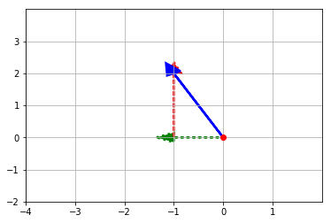

```python
# Import NumPy and Matplotlib
%matplotlib inline
import numpy as np
import matplotlib.pyplot as plt

# Define vector v
v = np.array([-1,2])

# Define basis vector i_hat as unit vector
i_hat = np.array([1,0])

# Define basis vector j_hat as unit vector
j_hat = np.array([0,1])

# Define v_ihat - as v[0](x) multiplied by basis vector ihat
v_ihat = v[0] * i_hat

# Define v_jhat_t - as v[1](y) multiplied by basis vector jhat
v_jhat = v[1] * j_hat

# Plot that graphically shows vector v (color='b') - whose position can be
# decomposed into v_ihat and v_jhat

# Creates axes of plot referenced 'ax'
ax = plt.axes()

# Plots red dot at origin (0,0)
ax.plot(0,0,'or')


# Plots vector v_ihat as dotted green arrow starting at origin 0,0
ax.arrow(0, 0, *v_ihat, color='g', linestyle='dotted', linewidth=2.5, head_width=0.30,
         head_length=0.35)

# Plots vector v_jhat as dotted red arrow starting at origin defined by v_ihat
ax.arrow(v_ihat[0], v_ihat[1], *v_jhat, color='r', linestyle='dotted', linewidth=2.5,
         head_width=0.30, head_length=0.35)

# Plots vector v as blue arrow starting at origin 0,0
ax.arrow(0, 0, *v, color='b', linewidth=2.5, head_width=0.30, head_length=0.35)


# Sets limit for plot for x-axis
plt.xlim(-4, 2)

# Set major ticks for x-axis
major_xticks = np.arange(-4, 2)
ax.set_xticks(major_xticks)


# Sets limit for plot for y-axis
plt.ylim(-2, 4)

# Set major ticks for y-axis
major_yticks = np.arange(-2, 4)
ax.set_yticks(major_yticks)

# Creates gridlines for only major tick marks
plt.grid(b=True, which='major')

# Displays final plot
plt.show()
```

## *Transforming* a Vector using *Transformed* Vectors $\vec{\hat{i_T}}$ and $\vec{\hat{j_T}}$

For this part of the lab, we will plot the results of *transforming* vector $\vec{v}$ using *transformed* vectors $\vec{\hat{i_T}}$ and $\vec{\hat{j_T}}$. Vectors $\vec{v}$, $\vec{\hat{i_T}}$, and $\vec{\hat{j_T}}$ have been defined below.

$\hspace{1cm}\vec{v} = \begin{bmatrix} -1\\ 2\end{bmatrix}$

$\hspace{1cm}\vec{\mathbin{\color{green}{\hat{i_T}}}} = \begin{bmatrix}\mathbin{\color{green}3}\\ \mathbin{\color{green}1} \end{bmatrix}$

$\hspace{1cm}\vec{\mathbin{\color{red}{\hat{j_T}}}} = \begin{bmatrix}\mathbin{\color{red}1}\\ \mathbin{\color{red}2} \end{bmatrix}$

### TODO: Computing and Plotting *Transformed* Vector $\vec{v_T}$ using Vectors $\vec{\hat{i_T}}$ and $\vec{\hat{j_T}}$

For this part of the lab you will be creating *transformed* vectors $\vec{\hat{i_T}}$ and $\vec{\hat{j_T}}$ and using them to *transform* vector $\vec{v}$ using *Equation 1* above.

1. Define vector $\vec{\hat{i_T}}$ by replacing $x$ and $y$ with $3$ and $1$ (see **TODO 1.:**).
2. Define vector $\vec{\hat{j_T}}$ by replacing $x$ and $y$ with $1$ and $2$ (see **TODO 2.:**).
3. Define vector $\vec{v_T}$ by adding vectors $\vec{\hat{i_T}}$ and $\vec{\hat{j_T}}$ (see **TODO 3.:**).
4. Plot vector $\vec{v_T}$ by copying the *ax.arrow(...)* statement for vector $\vec{v}$ and changing *color = 'b'* in the *ax.arrow(...)* statement to plot vector $\vec{v_T}$ as blue colored vector (see **TODO 4.:**).

**Notice that**:

- To *run* your code:
  - Click on the Save icon (disk icon right under *'File'* in the menu bar above), to save your work.
  - Select *'Kernel'* and *'Restart & Run All'*, to run your code.

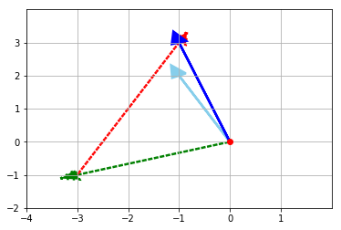

```python
# Define vector v
v = np.array([-1, 2])

# TODO 1.: Define vector i_hat as transformed vector i_hat(ihat_t)
# where x=3 and y=1 instead of x=1 and y=0
ihat_t = np.array([1, 0])
ihat = np.array([3,1])

# TODO 2.: Define vector j_hat as transformed vector j_hat(jhat_t)
# where x=1 and y=2 instead of x=0 and y=1
jhat_t = np.array([0, 1])
jhat = np.array([1,2])

# Define v_ihat_t - as v[0](x) multiplied by transformed vector ihat
v_ihat_t = v[0] * ihat

# Define v_jhat_t - as v[1](y) multiplied by transformed vector jhat
v_jhat_t = v[1] * jhat

# TODO 3.: Define transformed vector v (v_t) as
# vector v_ihat_t added to vector v_jhat_t
v_t = v_ihat_t + v_jhat_t


# Plot that graphically shows vector v (color='skyblue') can be transformed
# into transformed vector v (v_trfm - color='b') by adding v[0]*transformed
# vector ihat to v[0]*transformed vector jhat


# Creates axes of plot referenced 'ax'
ax = plt.axes()

# Plots red dot at origin (0,0)
ax.plot(0,0,'or')


# Plots vector v_ihat_t as dotted green arrow starting at origin 0,0
ax.arrow(0, 0, *v_ihat_t, color='g', linestyle='dotted', linewidth=2.5, head_width=0.30,
         head_length=0.35)

# Plots vector v_jhat_t as dotted red arrow starting at origin defined by v_ihat
ax.arrow(v_ihat_t[0], v_ihat_t[1], *v_jhat_t, color='r', linestyle='dotted', linewidth=2.5,
         head_width=0.30, head_length=0.35)

# Plots vector v as blue arrow starting at origin 0,0
ax.arrow(0, 0, *v, color='skyblue', linewidth=2.5, head_width=0.30, head_length=0.35)

# TODO 4.: Plot transformed vector v (v_t) a blue colored vector(color='b') using
# vector v's ax.arrow() statement above as template for the plot
ax.arrow(0, 0, *v_t, color='b', linewidth=2.5, head_width=0.30, head_length=0.35)


# Sets limit for plot for x-axis
plt.xlim(-4, 2)

# Set major ticks for x-axis
major_xticks = np.arange(-4, 2)
ax.set_xticks(major_xticks)


# Sets limit for plot for y-axis
plt.ylim(-2, 4)

# Set major ticks for y-axis
major_yticks = np.arange(-2, 4)
ax.set_yticks(major_yticks)

# Creates gridlines for only major tick marks
plt.grid(b=True, which='major')

# Displays final plot
plt.show()
```

### Solution for Computing and Plotting *Transformed* Vector $\vec{v_T}$

Your output from above should match the output below. If you need any help or want to check your answer, feel free to check out the solution notebook by clicking here.

[figure not shown]

### Solution Video for Computing and Plotting *Transformed* Vector $\vec{v_T}$

The solution video can be found in the **Linear Mapping Lab Solution** section. You may want to open another browser window to allow you to easily toggle between the Vector's Lab Jupyter Notebook and the solution videos for this lab.

## Matrix Multiplication

For this part of the lab, we will demonstrate that the same vector transformation from the section above can be achieved with matrix multiplication (*Equation 2*). Vectors $\vec{v}$ and $\vec{ij}$ have been defined below.

$\hspace{1cm}\vec{v} = \begin{bmatrix} -1\\ 2\end{bmatrix}$

$\hspace{1cm}\vec{ij} = \begin{bmatrix} \mathbin{\color{green}3} & \mathbin{\color{red}1}\\ \mathbin{\color{green}1} & \mathbin{\color{red}2}\end{bmatrix}$

### TODO: Matrix Multiplication

For this part of the lab, define **transformed** vector **$\vec{v_T}$** using the [function **matmul**](https://docs.scipy.org/doc/numpy-1.13.0/reference/generated/numpy.matmul.html) for multiplying 2x2 matrix **$\vec{ij}$** and vector **$\vec{v}$**.

1. Replace **None** below with code that defines **transformed** vector **$\vec{v_T}$** using the **matmul** function to multiply matrix **$\vec{ij}$** and vector **$\vec{v}$** (see **TODO 1.**)

**Notice that**:

- The alias **np** was used to with the import of the Numpy package; therefore, use the **np** alias when you call the **matmul** function below.
- To *run* your code:
  - Click on the Save icon (disk icon right under *'File'* in the menu bar above), to save your work.
  - Select *'Kernel'* and *'Restart & Run All'*, to run your code.

```python
# Define vector v
v = np.array([-1,2])

# Define 2x2 matrix ij
ij = np.array([[3, 1],[1, 2]])

# TODO 1.: Demonstrate getting v_trfm by matrix multiplication
# by using matmul function to multiply 2x2 matrix ij by vector v
# to compute the transformed vector v (v_t)
v_t = None

# Prints vectors v, ij, and v_t
print("\nMatrix ij:", ij, "\nVector v:", v, "\nTransformed Vector v_t:", v_t, sep="\n")
```

```
Matrix ij:
[[3 1]
 [1 2]]

Vector v:
[-1  2]

Transformed Vector v_t:
None
```

### Solution for Matrix Multiplication

Your output from above for *transformed* vector $\vec{v_T}$ should match the solution below. Notice that in NumPy vectors are written horizontally so that the *[-1 2]* from above is the way vector $\vec{v}$ will be defined. If you need any help or want to check your answer, feel free to check out the solution notebook by clicking here.

With this matrix multiplication you have completed the computation in *Equation 2* using *transformed* vectors $\vec{\hat{i_T}}$ and $\vec{\hat{j_T}}$ (see below).

$\hspace{1cm} \begin{bmatrix} \mathbin{\color{green}3} & \mathbin{\color{red}1}\\ \mathbin{\color{green}1} & \mathbin{\color{red}2}\end{bmatrix} \begin{bmatrix} -1\\ 2\end{bmatrix} = -1 \begin{bmatrix}\mathbin{\color{green}3}\\ \mathbin{\color{green}1} \end{bmatrix} + 2 \begin{bmatrix} \mathbin{\color{red}1}\\ \mathbin{\color{red}2} \end{bmatrix} = \begin{bmatrix} {-1}{*}\mathbin{\color{green}3} +\,2{*}\mathbin{\color{red}1}\\ {-1}{*}\mathbin{\color{green}1} +\, 2{*}\mathbin{\color{red}2}\end{bmatrix} = \begin{bmatrix} -1\\ 3\end{bmatrix}$

You expect the following value for *transformed* $\vec{v_T}$, it will be written by NumPy as *[-1 3]*:

$\hspace{1cm}\textit{tranformed }\ \vec{v_T} = \begin{bmatrix} -1\\ 3\end{bmatrix}$

### Solution Video for Matrix Multiplication

The solution video can be found in the **Linear Mapping Lab Solution** section. You may want to open another browser window to allow you to easily toggle between the Vector's Lab Jupyter Notebook and the solution videos for this lab.